# Final_Project_Report(1)

## Debug inference for emotion classification

```python
# Use smaller dataset for debugging settings
!ls "/content/drive/MyDrive/MIE1517 project/Emotional Speech Dataset (ESD)/3groupEng"
```

```
0011  0012  0013
```

```python
data_path = "/content/drive/MyDrive/MIE1517 project/Emotional Speech Dataset (ESD)/demo_test"
dataset_dataset = ESDDataset(data_path, feature_extractor)

#Set DataLoader
dataset_loader = DataLoader(dataset_dataset, batch_size=1, shuffle=False, collate_fn=collate_fn)
print(f"Testing set size: {len(dataset_dataset)}")

torch.manual_seed(1000)
device = torch.device("cuda" if torch.cuda.is_available() else "cpu")
dataset_features, dataset_labels = compute_features(dataset_loader, model, feature_extractor, device)
dataset_dataset = TensorDataset(dataset_features, dataset_labels)
print("Test Features Shape:", dataset_features.shape)
```

```
Find 250 audio samples.
Testing set size: 250
```

```
Test Features Shape: torch.Size([250, 768])
```

```python
device = torch.device("cuda" if torch.cuda.is_available() else "cpu")
# Load the trained model_2
model_2 = CNN(5)
model_2.load_state_dict(torch.load("/content/best_model_CNN_bs32_lr0.0005_epoch9_acc0.9238.pth", map_location=device))
model_2.to(device)
model_2.eval()
```

```
CNN(
  (conv1): Conv1d(768, 256, kernel_size=(3,), stride=(1,), padding=(1,))
  (bn1): BatchNorm1d(256, eps=1e-05, momentum=0.1, affine=True, track_running_stats=True)
  (pool): AdaptiveMaxPool1d(output_size=96)
  (conv2): Conv1d(256, 128, kernel_size=(3,), stride=(1,), padding=(1,))
  (bn2): BatchNorm1d(128, eps=1e-05, momentum=0.1, affine=True, track_running_stats=True)
  (conv3): Conv1d(128, 64, kernel_size=(3,), stride=(1,), padding=(1,))
  (bn3): BatchNorm1d(64, eps=1e-05, momentum=0.1, affine=True, track_running_stats=True)
  (fc1): Linear(in_features=6144, out_features=128, bias=True)
  (dropout): Dropout(p=0.5, inplace=False)
  (fc2): Linear(in_features=128, out_features=5, bias=True)
)
```

```python
# For testing
model = CNN(num_classes=5)
model.load_state_dict(torch.load("best_model_CNN_bs32_lr0.0005_epoch9_acc0.9238.pth", map_location=device))
model.to(device)
model.eval()
```

```
CNN(
  (conv1): Conv1d(768, 256, kernel_size=(3,), stride=(1,), padding=(1,))
  (bn1): BatchNorm1d(256, eps=1e-05, momentum=0.1, affine=True, track_running_stats=True)
  (pool): AdaptiveMaxPool1d(output_size=96)
  (conv2): Conv1d(256, 128, kernel_size=(3,), stride=(1,), padding=(1,))
  (bn2): BatchNorm1d(128, eps=1e-05, momentum=0.1, affine=True, track_running_stats=True)
  (conv3): Conv1d(128, 64, kernel_size=(3,), stride=(1,), padding=(1,))
  (bn3): BatchNorm1d(64, eps=1e-05, momentum=0.1, affine=True, track_running_stats=True)
  (fc1): Linear(in_features=6144, out_features=128, bias=True)
  (dropout): Dropout(p=0.5, inplace=False)
  (fc2): Linear(in_features=128, out_features=5, bias=True)
)
```

```python
# Confirm the label map
label_map = {0: "Neutral", 1: "Happy", 2: "Angry", 3: "Sad", 4: "Surprise"}
```

```python
# Load Wav2Vec2
model_name = "facebook/wav2vec2-base"
feature_extractor = Wav2Vec2FeatureExtractor.from_pretrained(model_name)
wav2vec2_model = Wav2Vec2Model.from_pretrained(model_name).to(device)
```

```python
# Define a function for prediction inference
def debug_inference(file_path, model, feature_extractor, wav2vec2_model, device):
    model.to(device).eval()
    wav2vec2_model.to(device).eval()

    # Load and preprocess audio
    audio, sr = librosa.load(file_path, sr=16000)
    print(f"🔊 Audio length: {len(audio) / sr:.2f} seconds")

    max_duration = 5
    max_samples = int(max_duration * sr)
    if len(audio) > max_samples:
        audio = audio[:max_samples]

    # Extract features using Wav2Vec2 feature extractor
    inputs = feature_extractor(audio, sampling_rate=sr, return_tensors="pt", padding=True)
    input_values = inputs["input_values"].to(device)

    with torch.no_grad():
        # Generate Wav2Vec2 embeddings
        features = wav2vec2_model(input_values).last_hidden_state  # [1, T, 768]
        print("📐 Wav2Vec2 output shape:", features.shape)

        # Forward through CNN
        outputs = model(features)  # logits shape: [1, 5]
        print("📈 Logits:", outputs)

        # Compute softmax probabilities
        probs = torch.softmax(outputs, dim=1).cpu().numpy().flatten()
        for i, prob in enumerate(probs):
            print(f"🔢 {label_map[i]}: {prob:.4f}")

        # Compute CrossEntropyLoss (for debug, using dummy label)
        dummy_label = torch.tensor([0], dtype=torch.long).to(device)
        criterion = nn.CrossEntropyLoss()
        loss = criterion(outputs, dummy_label).item()
        print(f"📉 Inference Loss (not meaningful, for shape check): {loss:.4f}")

        # Final prediction
        top_pred = torch.argmax(outputs, dim=1).item()
        print(f"✅ Predicted Emotion: {label_map[top_pred]}")
```

The function `debug_inference` is a debugging utility for:

- Verifying that the model pipeline (Wav2Vec2 + CNN) works end-to-end
- Inspecting shapes, logits, and softmax outputs
- Checking that audio is being correctly processed and classified

Test prediction performance

```python
# Test sample sad in Chinses
debug_inference(
    file_path="/content/0001_001400.wav",
    model=model,
    feature_extractor=feature_extractor,
    wav2vec2_model=wav2vec2_model,
    device=device
)
```

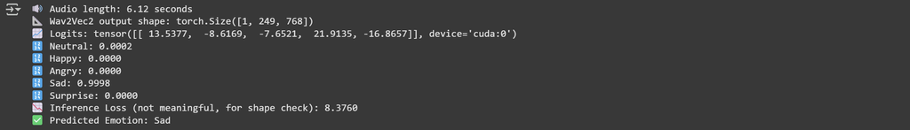

```python
# Test sample sad in English
debug_inference(
    file_path="/content/0012_001396.wav",
    model=model,
    feature_extractor=feature_extractor,
    wav2vec2_model=wav2vec2_model,
    device=device
)
```

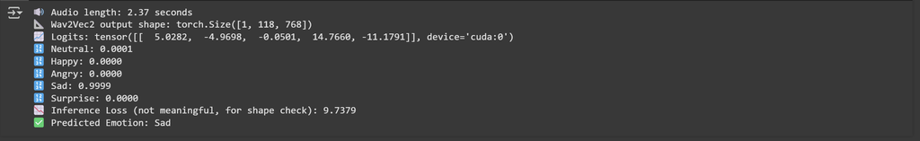

```python
# Test sample Neutral in Chinses
debug_inference(
    file_path="/content/0002_000350.wav",
    model=model,
    feature_extractor=feature_extractor,
    wav2vec2_model=wav2vec2_model,
    device=device
)
```

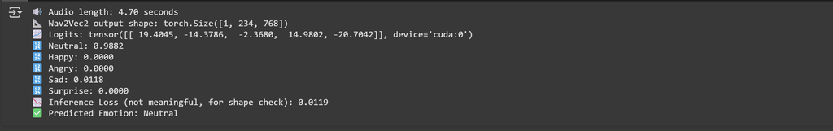

```python
# Test sample Neutral in English
debug_inference(
    file_path="/content/0012_000344.wav",
    model=model,
    feature_extractor=feature_extractor,
    wav2vec2_model=wav2vec2_model,
    device=device
)
```

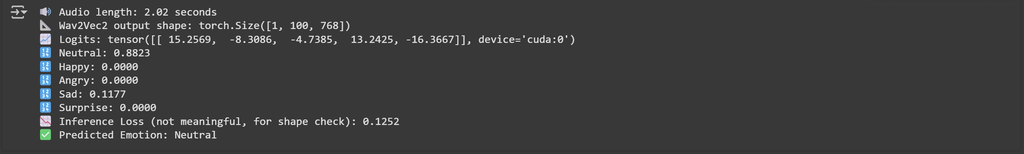

```python
# Test sample Angry in Chinese
debug_inference(
    file_path="/content/0002_000700.wav",
    model=model,
    feature_extractor=feature_extractor,
    wav2vec2_model=wav2vec2_model,
    device=device
)
```

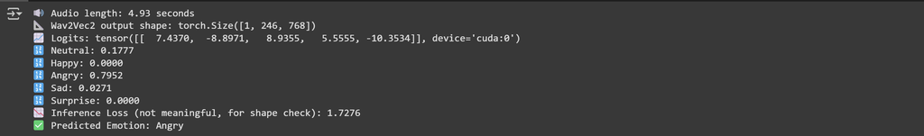

```python
# Test sample Angry in English
debug_inference(
    file_path="/content/0012_000688.wav",
    model=model,
    feature_extractor=feature_extractor,
    wav2vec2_model=wav2vec2_model,
    device=device
)
```

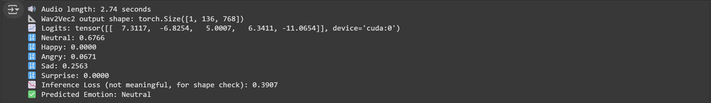

```python
# Test sample Surprise in English
debug_inference(
    file_path="/content/0012_001750.wav",
    model=model,
    feature_extractor=feature_extractor,
    wav2vec2_model=wav2vec2_model,
    device=device
)
```

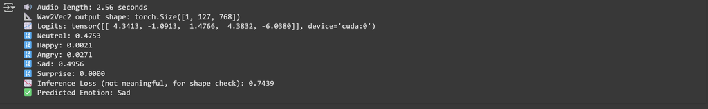

The model performs well on Sad and Neutral across both languages.  
It shows weaker performance on Surprise and some confusion between Angry and Neutral, especially in English samples.

## Model deployment on Hugging Face

[figure not shown]

## Final Discussion

1. Tensor shapes proper handling of tensor dimensions is critical. The output from Wav2Vec2 (last_hidden_state) has the shape [batch_size, sequence_length, feature_dim] (e.g., [1, T, 768]), which must be correctly formatted to feed into Conv1D layers in the CNN. Shape mismatches can lead to runtime errors or ineffective learning. Ensuring compatibility between Wav2Vec2 outputs and CNN expectations was a key step in building a stable inference pipeline.
2. Feature choice matters. After testing multiple options, we found that using last_hidden_state from Wav2Vec2 yields better downstream results than extract_features. This layer retains more contextual and sequential information, making it better suited for emotion recognition tasks. Selecting this representation significantly improved model performance.
3. Post-Model Processing via API To extend the model's utility beyond inference, we designed an interface for post-modeling tasks using an API.
4. ChatGPT Integration for user Interaction Model outputs can be piped into ChatGPT prompts to generate real-time, personalized responses based on predicted emotions. This creates an emotionally aware dialogue system.
5. We bridged the model with Hugging Face Spaces or custom frontends to deploy the system as an interactive web application. Key components include: File upload or microphone input, Real-time emotion feedback, Chat-based recommendations powered by the model and OpenAI API. This creates a user-friendly interface for emotion-aware entertainment or wellness applications.

## Limitations and future improvement

- Application costs are high, including model inference, cloud resources, and third-party APIs like Hugging Face and OpenAI tokens. The system is still weak in supporting diverse inputs. For example, different languages, accents, and audio quality. Low-latency processing is still a problem for a better user engagement. Emotion boundaries are often vague, leading to challenges in classifying mixed or transitional emotions.
- Improvements may involve temporal modeling or multi-label approaches. Balancing accuracy, speed, and user experience is key to successful deployment in real-world, interactive applications like emotion-aware chatbots or entertainment recommendation systems.